# Lezione 1 — Demo R

MAF, HWE e LD su 1000 Genomes / chr10 / T2D

Statistical Models for Genetics

Master in Biostatistica

# Setup operativo

## Come è strutturato il materiale

Questa demo gira sul **dataset reale** T2D / chr10 simulato a partire da 1000 Genomes Phase 3. Il file di partenza è:

```
data/T2D_chr10_clean.{bed,bim,fam}
```

## Pacchetti R richiesti

```r
# CRAN
install.packages(c("genio", "ggplot2", "dplyr"))

install.packages("remotes")
remotes::install_github("SFUStatgen/LDheatmap")

# Bioconductor
if (!requireNamespace("BiocManager", quietly = TRUE))
  install.packages("BiocManager")
BiocManager::install(c("snpStats", "SNPRelate"))
```

```r
library(genio)        # lettura PLINK
library(snpStats)     # ispezione e LD
library(LDheatmap)    # heatmap LD
library(ggplot2)
library(dplyr)
library(tidyr)
theme_set(theme_minimal(base_size = 13))
```

# 1. Caricamento del dataset

## Lettura del trio PLINK con `genio`

`genio::read_plink()` legge il `.bed/.bim/.fam` in un singolo passo. Per il chr10 (676k SNP × 2504 individui) impiega circa 30-60 secondi.

```r
setwd("/Users/annasandionigi/Documents/Courses/ModelliGenetici/materiale_demoR_modelli_statistici/")
```

```r
plink_path <- "./data/T2D_chr10/T2D_chr10_clean"
dat <- read_plink(plink_path)

# Cosa contiene `dat`:
str(dat, max.level = 1)
```

```
## List of 3
##  $ X  : int [1:676148, 1:2504] 0 0 2 0 1 0 0 0 0 0 ...
##   ..- attr(*, "dimnames")=List of 2
##  $ bim: spc_tbl_ [676,148 × 6] (S3: spec_tbl_df/tbl_df/tbl/data.frame)
##   ..- attr(*, "spec")=
##   .. .. cols(
##   .. ..   chr = col_character(),
##   .. ..   id = col_character(),
##   .. ..   posg = col_double(),
##   .. ..   pos = col_integer(),
##   .. ..   alt = col_character(),
##   .. ..   ref = col_character()
##   .. .. )
##  $ fam: spc_tbl_ [2,504 × 6] (S3: spec_tbl_df/tbl_df/tbl/data.frame)
##   ..- attr(*, "spec")=
##   .. .. cols(
##   .. ..   fam = col_character(),
##   .. ..   id = col_character(),
##   .. ..   pat = col_character(),
##   .. ..   mat = col_character(),
##   .. ..   sex = col_integer(),
##   .. ..   pheno = col_double()
##   .. .. )
```

L’oggetto contiene tre componenti:

- `X` — matrice di genotipi `n_snp × n_ind`, valori in {0, 1, 2, NA}
- `bim` — data frame con info per-SNP
- `fam` — data frame con info per-individuo

```r
G   <- dat$X
bim <- dat$bim
fam <- dat$fam

cat(sprintf("Dimensioni di G: %s SNP × %s individui\n",
            format(nrow(G), big.mark = ","),
            format(ncol(G), big.mark = ",")))
```

```
## Dimensioni di G: 676,148 SNP × 2,504 individui
```

**Nota sull’orientamento**: `genio` restituisce la matrice nella forma *SNP × individui* (righe = SNP, colonne = individui), che è la convenzione di PLINK. Nella maggior parte dei manuali di statistica genetica si usa la trasposta (individui × SNP). Per le formule che vedremo a lezione useremo *n_ind × n_snp*; quando serve, basta trasporre con `t()`.

# 2. Ispezione di `.bim` e `.fam`

## `.bim` — informazioni per-SNP

```r
head(bim, 10)
```

| chr | id | posg | pos | alt | ref |
| --- | --- | --- | --- | --- | --- |
| 10 | rs112920234 | 0 | 60523 | G | T |
| 10 | rs569167217 | 0 | 60684 | C | A |
| 10 | rs61838556 | 0 | 60969 | A | C |
| 10 | rs548639866 | 0 | 61331 | G | A |
| 10 | rs147855157 | 0 | 61372 | C | CA |
| 10 | rs536439816 | 0 | 61386 | A | G |
| 10 | rs553163044 | 0 | 61419 | A | G |
| 10 | rs558589576 | 0 | 61594 | T | C |
| 10 | rs546443136 | 0 | 61694 | G | T |
| 10 | rs568474105 | 0 | 62010 | T | C |

**Cosa stiamo guardando**: ogni riga è uno SNP. Le colonne:

- `chr` — cromosoma (10, in questo caso)
- `id` — identificativo rsID (tutti gli SNP del nostro dataset hanno rsID, perché abbiamo filtrato i nameless in fase di preparazione)
- `posg` — distanza genetica in centiMorgan (sempre 0, non usata)
- `pos` — posizione fisica in basi (GRCh37)
- `alt` — allele alternativo (A1 in PLINK)
- `ref` — allele di riferimento (A2 in PLINK)

## Ricerca del top SNP T2D — rs7903146 (TCF7L2)

```r
tcf7l2_row <- bim[bim$id == "rs7903146", ]
tcf7l2_row
```

| chr | id | posg | pos | alt | ref |
| --- | --- | --- | --- | --- | --- |
| 10 | rs7903146 | 0 | 114758349 | T | C |

**Posizione canonica**: chr10:114.758.349 in GRCh37. Lo confermiamo.

## `.fam` — informazioni per-individuo

```r
head(fam, 10)
```

| fam | id | pat | mat | sex | pheno |
| --- | --- | --- | --- | --- | --- |
| HG00096 | HG00096 | 0 | 0 | 0 | 1 |
| HG00097 | HG00097 | 0 | 0 | 0 | 1 |
| HG00099 | HG00099 | 0 | 0 | 0 | 1 |
| HG00100 | HG00100 | 0 | 0 | 0 | 1 |
| HG00101 | HG00101 | 0 | 0 | 0 | 1 |
| HG00102 | HG00102 | 0 | 0 | 0 | 1 |
| HG00103 | HG00103 | 0 | 0 | 0 | 1 |
| HG00105 | HG00105 | 0 | 0 | 0 | 1 |
| HG00106 | HG00106 | 0 | 0 | 0 | 1 |
| HG00107 | HG00107 | 0 | 0 | 0 | 1 |

**Codifica del fenotipo (caso-controllo)**:

- `1` = controllo
- `2` = caso
- `0` o `-9` = mancante / non simulato

```r
table(fam$pheno, dnn = "fenotipo T2D")
```

```
## fenotipo T2D
##   -9    1    2
##    4 2250  250
```

Confermati: ~250 casi, ~2250 controlli, qualche NA residuo della simulazione GCTA.

## Pannello 1000G — super-popolazioni

Carichiamo anche il pannello dei sample di 1000G, che ci dice da quale super-popolazione viene ogni individuo. Lo useremo nell’ultimo grafico.

```r
panel <- read.table("./data/integrated_call_samples_v3.20130502.ALL.panel",
                    header = TRUE, stringsAsFactors = FALSE)
fam$super_pop <- panel$super_pop[match(fam$id, panel$sample)]

table(fam$super_pop, useNA = "ifany")
```

```
##
## AFR AMR EAS EUR SAS
## 661 347 504 503 489
```

Cinque super-popolazioni rappresentate in modo bilanciato — questo darà problemi di stratificazione che vedremo alla Lezione 3.

# 3. Frequenze alleliche e MAF

## Calcolo vettorializzato

Per calcolare la frequenza dell’allele alternativo su tutti i 676k SNP usiamo l’identità: $p_{\text{ALT}} = \bar{G}_{\cdot j} / 2$, cioè **media della riga divisa per 2** (in `genio` le righe sono gli SNP).

```r
# Frequenza dell'allele alternativo per ogni SNP
freq_alt <- rowMeans(G, na.rm = TRUE) / 2

# MAF
maf <- pmin(freq_alt, 1 - freq_alt)

summary(maf)
```

```
##    Min. 1st Qu.  Median    Mean 3rd Qu.    Max.
## 0.01018 0.02376 0.07748 0.14291 0.23662 0.50000
```

## Spettro delle frequenze alleliche

Lo spettro è il grafico diagnostico fondamentale di ogni dataset GWAS.

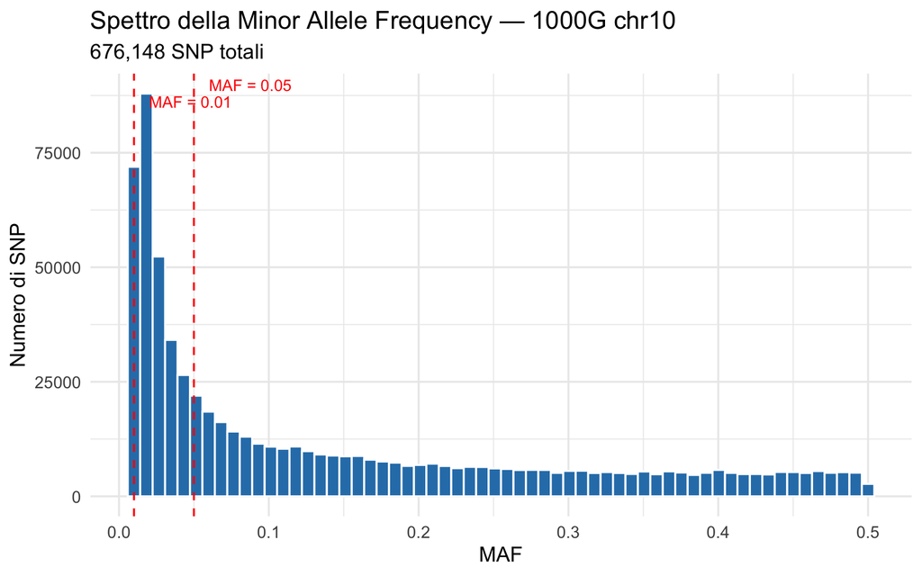

Spettro della MAF su chr10 (1000G Phase 3 + filtro MAF > 0.01)

```r
ggplot(data.frame(maf = maf), aes(x = maf)) +
  geom_histogram(bins = 60, fill = "#2c7fb8", color = "white") +
  geom_vline(xintercept = c(0.01, 0.05), linetype = "dashed", color = "red") +
  annotate("text", x = 0.06, y = Inf, label = "MAF = 0.05",
           color = "red", vjust = 1.5, hjust = 0, size = 3.5) +
  annotate("text", x = 0.02, y = Inf, label = "MAF = 0.01",
           color = "red", vjust = 3, hjust = 0, size = 3.5) +
  labs(
    x = "MAF", y = "Numero di SNP",
    title = "Spettro della Minor Allele Frequency — 1000G chr10",
    subtitle = sprintf("%s SNP totali", format(length(maf), big.mark = ","))
  )
```

**Interpretazione in aula**:

- la **massa principale** è tra 0.05 e 0.50 → SNP comuni, fulcro dell’analisi GWAS
- la **coda a sinistra** sotto 0.05 contiene SNP a bassa frequenza, da trattare con cautela
- la forma decrescente “L” è tipica delle popolazioni umane — moltissime varianti rare, poche comuni — riflette la storia demografica della specie

## Tabella per categoria

```r
maf_class <- cut(maf,
  breaks = c(-Inf, 0.01, 0.05, 0.5),
  labels = c("rare (<1%)", "bassa freq. (1-5%)", "comuni (≥5%)")
)
data.frame(
  classe = names(table(maf_class)),
  N      = as.integer(table(maf_class)),
  `%`    = round(100 * as.integer(table(maf_class)) / length(maf), 2)
)
```

| classe | N | X. |
| --- | --- | --- |
| rare (<1%) | 0 | 0.00 |
| bassa freq. (1-5%) | 280448 | 41.48 |
| comuni (≥5%) | 395700 | 58.52 |

Sotto 0.01 abbiamo zero SNP per costruzione (filtraggio MAF > 0.01 in fase di preparazione). Tra 1% e 5% c’è una coda di varianti a bassa frequenza, e la maggior parte sono comuni.

# 4. Equilibrio di Hardy–Weinberg

## Test χ² su un singolo SNP (calcolo manuale)

Riprendiamo rs7903146 e calcoliamo HWE a mano, per fissare l’algebra:

```r
g_tcf <- G["rs7903146", ]
n     <- sum(!is.na(g_tcf))

# Conteggi genotipici
o_AA  <- sum(g_tcf == 0, na.rm = TRUE)
o_Aa  <- sum(g_tcf == 1, na.rm = TRUE)
o_aa  <- sum(g_tcf == 2, na.rm = TRUE)

# Frequenza allelica
p     <- (2 * o_AA + o_Aa) / (2 * n)
q     <- 1 - p

# Frequenze attese sotto HWE
e_AA  <- n * p^2
e_Aa  <- n * 2 * p * q
e_aa  <- n * q^2

# χ²
X2    <- (o_AA - e_AA)^2 / e_AA +
         (o_Aa - e_Aa)^2 / e_Aa +
         (o_aa - e_aa)^2 / e_aa

p_val <- pchisq(X2, df = 1, lower.tail = FALSE)

data.frame(
  metrica    = c("n", "AA (oss.)", "Aa (oss.)", "aa (oss.)",
                 "AA (att.)", "Aa (att.)", "aa (att.)",
                 "MAF", "X²", "HWE p-value"),
  valore     = c(n, o_AA, o_Aa, o_aa,
                 round(e_AA,1), round(e_Aa,1), round(e_aa,1),
                 round(min(p, q),3), round(X2,3),
                 formatC(p_val, digits = 3))
)
```

| metrica | valore |
| --- | --- |
| n | 2504 |
| AA (oss.) | 1534 |
| Aa (oss.) | 799 |
| aa (oss.) | 171 |
| AA (att.) | 1493 |
| Aa (att.) | 881 |
| aa (att.) | 130 |
| MAF | 0.228 |
| X² | 21.712 |
| HWE p-value | 3.17e-06 |

## Calcolo vettorializzato su tutti gli SNP — con `snpStats`

Per fare HWE su 676k SNP in pochi secondi, ci affidiamo a `snpStats::col.summary()`. Per usarla servono i dati in formato `SnpMatrix` — la rilettiamo direttamente da `snpStats::read.plink()`, che usa un formato compatto (1 byte per genotipo) e non sfora mai la RAM:

```r
# read.plink legge direttamente in SnpMatrix (formato byte-packed, memoria minima)
plink_data <- snpStats::read.plink(
  bed = paste0(plink_path, ".bed"),
  bim = paste0(plink_path, ".bim"),
  fam = paste0(plink_path, ".fam")
)
snp_mat <- plink_data$genotypes   # già SnpMatrix
cat(sprintf("SnpMatrix: %d individui × %d SNP, memoria ~%.1f MB\n",
            nrow(snp_mat), ncol(snp_mat),
            as.numeric(object.size(snp_mat)) / 1024^2))
```

```
## SnpMatrix: 2504 individui × 676148 SNP, memoria ~1661.2 MB
```

```r
# Statistiche per SNP — include HWE z-score
cs <- col.summary(snp_mat)

# z di HWE → p-value (test bilaterale, chi-quadro a 1 gdl)
hwe_p <- pchisq(cs$z.HWE^2, df = 1, lower.tail = FALSE)

cat("\nDistribuzione HWE p-values:\n")
```

```
##
## Distribuzione HWE p-values:
```

```r
print(summary(hwe_p))
```

```
##      Min.   1st Qu.    Median      Mean   3rd Qu.      Max.
## 0.000e+00 2.200e-07 2.441e-03 1.286e-01 1.506e-01 1.000e+00
```

## Distribuzione dei p-value di HWE

Sotto $H_0$ (HWE vale ovunque) i p-value sono **uniformi su [0, 1]**.

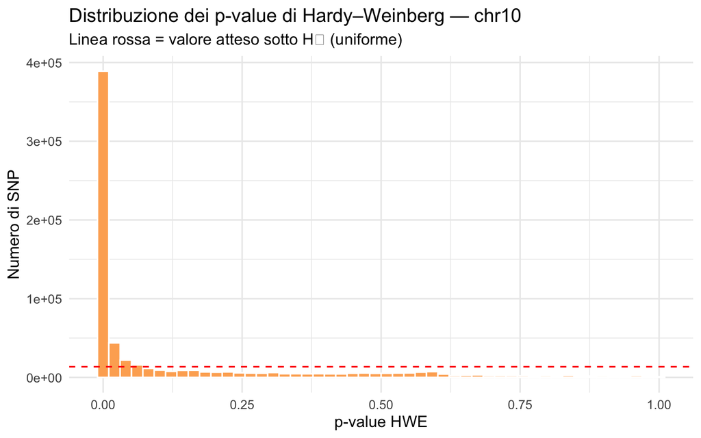

P-value HWE — atteso ~uniforme sotto H₀

```r
ggplot(data.frame(p = hwe_p[!is.na(hwe_p)]), aes(x = p)) +
  geom_histogram(bins = 50, fill = "#fdae61", color = "white") +
  geom_hline(yintercept = sum(!is.na(hwe_p)) / 50, linetype = "dashed", color = "red") +
  labs(
    x = "p-value HWE", y = "Numero di SNP",
    title = "Distribuzione dei p-value di Hardy–Weinberg — chr10",
    subtitle = "Linea rossa = valore atteso sotto H₀ (uniforme)"
  )
```

**Interpretazione**:

- la distribuzione mostra un **eccesso vicino a 0** — perché?
- nel nostro caso, ricordiamo che il dataset contiene **5 super-popolazioni mescolate**. Una popolazione strutturata (Wahlund effect) viola sistematicamente HWE → vediamo un’inflazione del test
- in un dataset omogeneo per ancestry l’istogramma sarebbe piatto
- **questo è uno dei motivi per cui il filtro HWE si applica per sub-popolazione, o dopo aver risolto la stratificazione (L3)**

## Quanti SNP supererebbero la soglia GWAS standard ($p < 10^{-6}$)?

```r
n_hwe_fail <- sum(hwe_p < 1e-6, na.rm = TRUE)
cat(sprintf("SNP che falliscono HWE a p < 1e-6: %s su %s totali (%.2f%%)\n",
            format(n_hwe_fail, big.mark = ","),
            format(sum(!is.na(hwe_p)), big.mark = ","),
            100 * n_hwe_fail / sum(!is.na(hwe_p))))
```

```
## SNP che falliscono HWE a p < 1e-6: 186,204 su 676,148 totali (27.54%)
```

Sono molti — perché il nostro dataset è multi-ancestry. Nel Lab 2 vedrete come questo numero scende drasticamente *dopo* aver risolto la stratificazione di popolazione.

# 5. Linkage Disequilibrium

## r² tra due SNP — calcolo diretto

```r
# rs7903146 e uno SNP molto vicino
snp1 <- G["rs7903146", ]

# Prendiamo lo SNP nella riga successiva del .bim (vicino fisicamente)
neighbor_id  <- bim$id[which(bim$id == "rs7903146") + 1]
snp2 <- G[neighbor_id, ]

r  <- cor(snp1, snp2, use = "pairwise.complete.obs")
r2 <- r^2

cat(sprintf("r²(rs7903146, %s) = %.3f\n", neighbor_id, r2))
```

```
## r²(rs7903146, rs115626858) = 0.004
```

## Decadimento dell’LD intorno a TCF7L2

Calcoliamo $r^2$ tra rs7903146 e tutti gli SNP in una finestra di ±200 kb, e plottiamo il decadimento.

```r
center_pos <- bim$pos[bim$id == "rs7903146"]
window_idx <- which(bim$chr == 10 & abs(bim$pos - center_pos) <= 200000)

cat(sprintf("SNP nella finestra ±200 kb: %d\n", length(window_idx)))
```

```
## SNP nella finestra ±200 kb: 1472
```

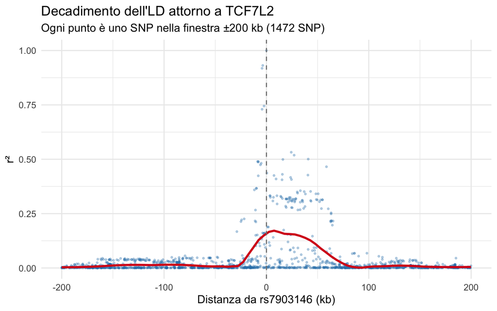

Decadimento dell’LD attorno a TCF7L2 (rs7903146)

```r
# r² rispetto a rs7903146
tcf_geno <- G["rs7903146", ]
r2_window <- sapply(window_idx, function(j) {
  if (bim$id[j] == "rs7903146") return(1)
  cor(tcf_geno, G[j, ], use = "pairwise.complete.obs")^2
})

ld_df <- data.frame(
  dist_kb = (bim$pos[window_idx] - center_pos) / 1000,
  r2      = r2_window
)

ggplot(ld_df, aes(x = dist_kb, y = r2)) +
  geom_point(alpha = 0.3, color = "#2c7fb8", size = 0.7) +
  geom_smooth(method = "loess", span = 0.2, color = "#d7191c", se = FALSE) +
  geom_vline(xintercept = 0, linetype = "dashed", color = "grey50") +
  labs(
    x = "Distanza da rs7903146 (kb)", y = "r²",
    title = "Decadimento dell'LD attorno a TCF7L2",
    subtitle = sprintf("Ogni punto è uno SNP nella finestra ±200 kb (%d SNP)", length(window_idx))
  )
```

**Cosa mostrare in aula**:

- al centro $r^2 = 1$ (lo SNP con sé stesso)
- la nube cala fino a ~50 kb e poi diventa rumore
- la curva LOESS (rossa) mostra il pattern medio del decadimento
- **questo è il blocco LD di TCF7L2 in popolazione mista** — è esteso ~50 kb, coerente con la struttura LD aspettata

## LD heatmap della regione TCF7L2 — con `snpStats`/`LDheatmap`

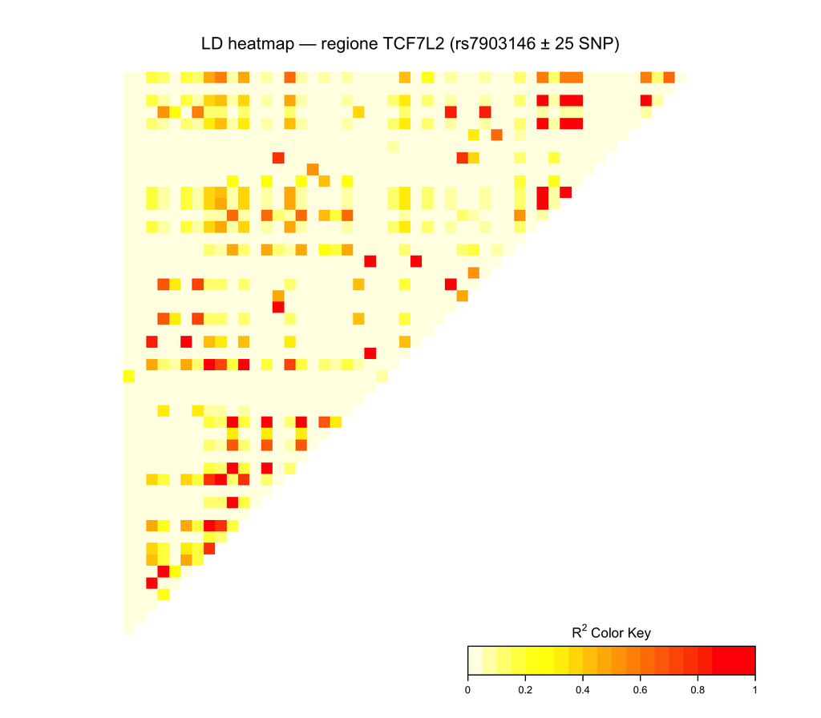

LD heatmap intorno a rs7903146 — 50 SNP nella regione

```r
# Selezioniamo 50 SNP intorno al top hit
tcf_idx <- which(bim$id == "rs7903146")
heatmap_idx <- (tcf_idx - 24):(tcf_idx + 25)
heatmap_idx <- heatmap_idx[heatmap_idx >= 1 & heatmap_idx <= nrow(G)]

# Estraiamo dalla SnpMatrix
snp_mat_subset <- snp_mat[, heatmap_idx]

# LDheatmap richiede SnpMatrix + posizioni fisiche
LDheatmap(snp_mat_subset,
          genetic.distances = bim$pos[heatmap_idx],
          color = heat.colors(20),
          title = "LD heatmap — regione TCF7L2 (rs7903146 ± 25 SNP)",
          add.map = FALSE,
          add.key = TRUE)
```

- il blocco di colore intenso al centro è il blocco aplotipico TCF7L2
- gli angoli (SNP più lontani) hanno r² basso
- nel Lab 1 confronterete questo blocco con un altro locus a vostra scelta — vedrete che blocchi diversi hanno dimensioni completamente diverse

# 6. Identificare rs7903146 — il top SNP T2D

```r
g_tcf <- G["rs7903146", ]
r2_high <- sum(r2_window >= 0.8) - 1  # esclude sé stesso

data.frame(
  metrica = c(
    "Posizione (GRCh37)",
    "MAF nel dataset (multi-ancestry)",
    "N omozigote ref (CC)",
    "N eterozigote (CT)",
    "N omozigote alt (TT)",
    "HWE p-value",
    "SNP in r² ≥ 0.8 nella regione ±200 kb"
  ),
  valore = c(
    format(bim$pos[bim$id == "rs7903146"], big.mark = ","),
    round(maf[which(bim$id == "rs7903146")], 3),
    sum(g_tcf == 0, na.rm = TRUE),
    sum(g_tcf == 1, na.rm = TRUE),
    sum(g_tcf == 2, na.rm = TRUE),
    formatC(hwe_p[which(bim$id == "rs7903146")], digits = 3, format = "g"),
    r2_high
  )
)
```

| metrica | valore |
| --- | --- |
| Posizione (GRCh37) | 114,758,349 |
| MAF nel dataset (multi-ancestry) | 0.228 |
| N omozigote ref (CC) | 1534 |
| N eterozigote (CT) | 799 |
| N omozigote alt (TT) | 171 |
| HWE p-value | 3.17e-06 |
| SNP in r² ≥ 0.8 nella regione ±200 kb | 2 |

# 7. Preview di L3 — struttura di popolazione in 1000G

Solo come anteprima visiva, calcoliamo le prime due componenti principali del nostro dataset e le coloriamo per super-popolazione. **Il metodo lo vedremo in dettaglio nelle prossime lezioni* — qui è solo per mostrarvi cosa c’è dentro i dati.

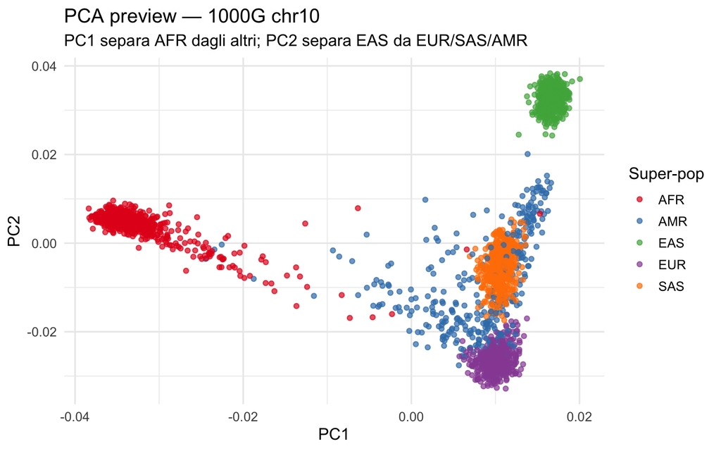

Preview: PC1 vs PC2 su 1000G chr10, colorata per super-popolazione

```r
# Per la velocità: PCA su un sottoinsieme casuale di 10k SNP comuni
set.seed(20260101)

# Stats per filtrare SNP comuni con basso missingness
keep_snps <- which(cs$MAF >= 0.05 & cs$Call.rate >= 0.99)
sample_idx <- sample(keep_snps, min(10000, length(keep_snps)))

# Estraiamo il subset dalla SnpMatrix
snp_sub <- snp_mat[, sample_idx]

# snpStats ha una funzione efficiente per la matrice X X^T che ci serve per la PCA
# Tratta automaticamente i NA come "imputati alla media" — perfetto per la preview
xxt <- snpStats::xxt(snp_sub, correct.for.missing = TRUE)

# Eigendecomposition di XX^T (più piccola: 2504 × 2504, gestibile)
eig <- eigen(xxt, symmetric = TRUE)

pc_df <- data.frame(
  PC1 = eig$vectors[, 1],
  PC2 = eig$vectors[, 2],
  super_pop = fam$super_pop
)

ggplot(pc_df, aes(x = PC1, y = PC2, color = super_pop)) +
  geom_point(alpha = 0.7, size = 1.5) +
  scale_color_brewer(palette = "Set1", name = "Super-pop") +
  labs(
    title = "PCA preview — 1000G chr10",
    subtitle = "PC1 separa AFR dagli altri; PC2 separa EAS da EUR/SAS/AMR",
    x = "PC1", y = "PC2"
  )
```

- vedete cluster chiaramente distinti per ancestry — questa è la **stratificazione di popolazione**
- è la fonte principale di falsi positivi nei GWAS multi-ancestry
- nella Lezione su dimensionality reduction impareremo a usare queste componenti come covariate nel modello per neutralizzarla

# 8. Proviamo a cambiare un po’ le carte:

Questo Lab consiste nel ripetere questa demo sui vostri laptop, con tre estensioni:

1. **MAF stratificata per super-popolazione** (AFR, EAS, EUR, AMR, SAS). Vedrete che la MAF di rs7903146 è ~0.30 in EUR, ma ha valori molto diversi in altre popolazioni — perché?

## 1a. Calcolo della MAF per ogni super-popolazione

```r
# Le 5 super-popolazioni presenti nel dataset
pops <- sort(unique(fam$super_pop[!is.na(fam$super_pop)]))
cat("Super-popolazioni:", paste(pops, collapse = ", "), "\n")
```

```
## Super-popolazioni: AFR, AMR, EAS, EUR, SAS
```

```r
# Funzione: frequenza dell'allele alternativo per un sottoinsieme di individui
#   G è snp × ind, quindi selezioniamo le COLONNE degli individui della pop
freq_alt_in_pop <- function(pop_label) {
  cols <- which(fam$super_pop == pop_label)
  rowMeans(G[, cols], na.rm = TRUE) / 2
}

# Calcoliamo la freq ALT per ogni pop → matrice snp × pop
freq_by_pop <- sapply(pops, freq_alt_in_pop)
colnames(freq_by_pop) <- pops

# MAF per pop (min(p, 1-p) applicato elemento per elemento)
maf_by_pop <- pmin(freq_by_pop, 1 - freq_by_pop)

# Anteprima
head(maf_by_pop)
```

```
##                     AFR         AMR          EAS         EUR         SAS
## rs112920234 0.065052950 0.004322767 0.0000000000 0.001988072 0.000000000
## rs569167217 0.003782148 0.023054755 0.0009920635 0.030815109 0.009202454
## rs61838556  0.443267776 0.497118156 0.2103174603 0.301192843 0.441717791
## rs548639866 0.003782148 0.023054755 0.0019841270 0.030815109 0.009202454
## rs147855157 0.394856278 0.384726225 0.4583333333 0.278330020 0.443762781
## rs536439816 0.038577912 0.001440922 0.0000000000 0.000000000 0.000000000
```

## 1b. Focus su rs7903146 (TCF7L2)

```r
tcf_idx <- which(bim$id == "rs7903146")

# Frequenza dell'allele ALT (= T, l'allele di rischio) per pop
tcf_freq <- data.frame(
  super_pop = pops,
  freq_T    = round(freq_by_pop[tcf_idx, ], 3),
  MAF       = round(maf_by_pop[tcf_idx, ], 3)
)
tcf_freq
```

|  | super_pop | freq_T | MAF |
| --- | --- | --- | --- |
| AFR | AFR | 0.260 | 0.260 |
| AMR | AMR | 0.235 | 0.235 |
| EAS | EAS | 0.023 | 0.023 |
| EUR | EUR | 0.317 | 0.317 |
| SAS | SAS | 0.299 | 0.299 |

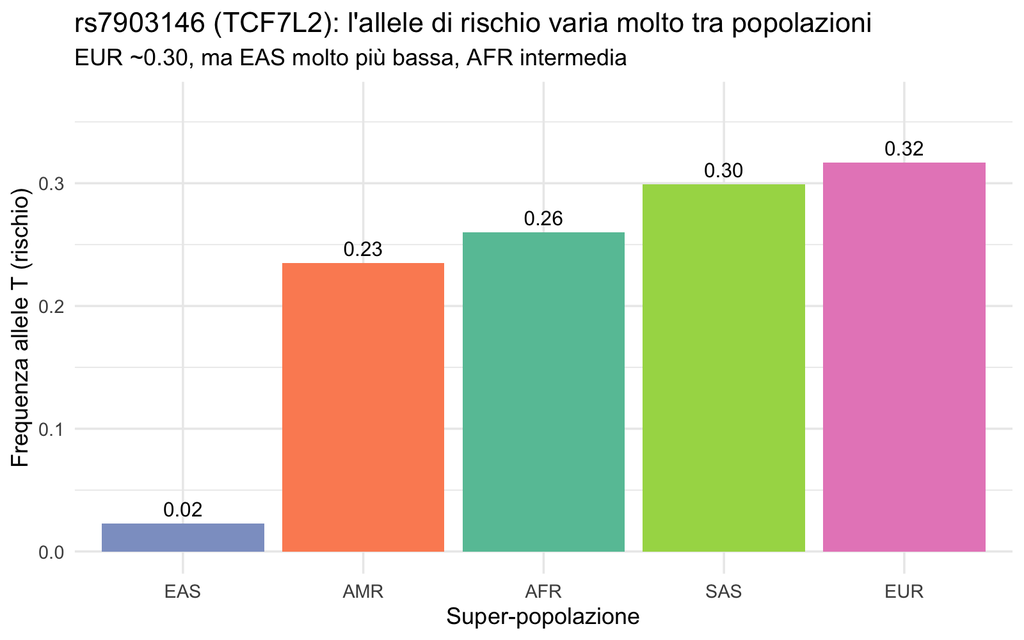

Frequenza dell’allele di rischio T (rs7903146) per super-popolazione

```r
ggplot(tcf_freq, aes(x = reorder(super_pop, freq_T), y = freq_T, fill = super_pop)) +
  geom_col(show.legend = FALSE) +
  geom_text(aes(label = sprintf("%.2f", freq_T)), vjust = -0.5, size = 4) +
  scale_fill_brewer(palette = "Set2") +
  ylim(0, max(tcf_freq$freq_T) * 1.15) +
  labs(
    x = "Super-popolazione", y = "Frequenza allele T (rischio)",
    title = "rs7903146 (TCF7L2): l'allele di rischio varia molto tra popolazioni",
    subtitle = "EUR ~0.30, ma EAS molto più bassa, AFR intermedia"
  )
```

**Risposta alla domanda “perché?”** :

La frequenza dell’allele di rischio di rs7903146 varia tra popolazioni per ragioni di **storia evolutiva e deriva genetica**. L’allele T è sorto in una popolazione ancestrale e la sua frequenza attuale riflette migrazioni, bottleneck demografici e (possibilmente) selezione locale. Questo ha due implicazioni dirette per il GWAS:

1. **Confondimento da stratificazione**: se casi e controlli hanno proporzioni diverse di ancestry, una variante con frequenza diversa tra popolazioni può apparire associata alla malattia *anche se non lo è*. È il problema centrale delle prossime lezioni.
2. **Portabilità dei risultati**: un OR stimato in EUR potrebbe non valere in EAS, sia perché la frequenza è diversa sia perché il pattern di LD con la variante causale cambia. Tema della L6 (PRS e portabilità).

## 1c. Confronto visivo su un campione di SNP

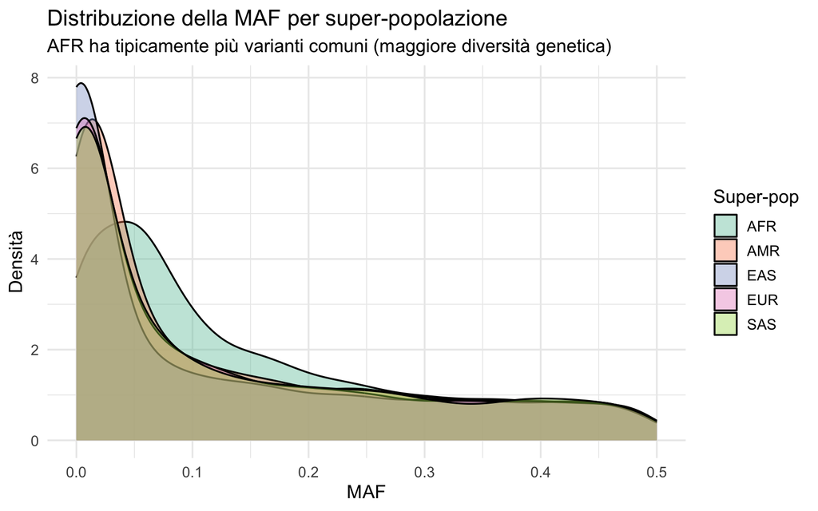

Distribuzione della MAF nelle 5 super-popolazioni (campione di 5000 SNP)

```r
set.seed(20260101)
sample_snps <- sample(nrow(maf_by_pop), 5000)

maf_long <- as.data.frame(maf_by_pop[sample_snps, ]) %>%
  pivot_longer(everything(), names_to = "super_pop", values_to = "maf")

ggplot(maf_long, aes(x = maf, fill = super_pop)) +
  geom_density(alpha = 0.4) +
  scale_fill_brewer(palette = "Set2", name = "Super-pop") +
  labs(
    x = "MAF", y = "Densità",
    title = "Distribuzione della MAF per super-popolazione",
    subtitle = "AFR ha tipicamente più varianti comuni (maggiore diversità genetica)"
  )
```

AFR mostra in genere una distribuzione con più varianti comuni — riflette la maggiore diversità genetica delle popolazioni africane, conseguenza dell’origine africana della specie e del bottleneck “out of Africa” subito dalle altre popolazioni.

2. **Decadimento LD su un secondo locus** a vostra scelta. Provate con un SNP a caso fuori da TCF7L2 — vedrete blocchi LD di dimensioni completamente diverse.

## 2a. Funzione riutilizzabile per il decadimento dell’LD

```r
# Calcola r² tra un SNP "indice" e tutti gli SNP nella finestra ±window_kb
ld_decay_around <- function(index_id, window_kb = 200) {
  idx <- which(bim$id == index_id)
  if (length(idx) == 0) stop("SNP non trovato: ", index_id)

  center_pos <- bim$pos[idx]
  center_chr <- bim$chr[idx]
  window_bp  <- window_kb * 1000

  win_idx <- which(bim$chr == center_chr &
                   abs(bim$pos - center_pos) <= window_bp)

  index_geno <- G[idx, ]
  r2 <- sapply(win_idx, function(j) {
    if (j == idx) return(1)
    cor(index_geno, G[j, ], use = "pairwise.complete.obs")^2
  })

  data.frame(
    snp_id  = bim$id[win_idx],
    dist_kb = (bim$pos[win_idx] - center_pos) / 1000,
    r2      = r2
  )
}
```

## 2b. Confronto: TCF7L2 vs un secondo locus

```r
# Scegliamo un secondo locus: prendiamo HHEX/IDE (rs1111875, altro causal T2D)
# In alternativa gli studenti possono scegliere uno SNP a caso comune.

# SNP indice 1: TCF7L2
locus1_id <- "rs7903146"

# SNP indice 2: HHEX (se presente), altrimenti uno SNP comune a caso sul chr10
if ("rs1111875" %in% bim$id) {
  locus2_id <- "rs1111875"
  locus2_name <- "HHEX/IDE"
} else {
  set.seed(42)
  common_snps <- bim$id[which(maf >= 0.2)]
  locus2_id <- sample(common_snps, 1)
  locus2_name <- "SNP casuale"
}

cat("Locus 1:", locus1_id, "(TCF7L2)\n")
```

```
## Locus 1: rs7903146 (TCF7L2)
```

```r
cat("Locus 2:", locus2_id, "(", locus2_name, ")\n")
```

```
## Locus 2: rs1111875 ( HHEX/IDE )
```

```r
ld1 <- ld_decay_around(locus1_id, window_kb = 200)
ld2 <- ld_decay_around(locus2_id, window_kb = 200)

ld1$locus <- paste0(locus1_id, " (TCF7L2)")
ld2$locus <- paste0(locus2_id, " (", locus2_name, ")")
ld_both <- rbind(ld1, ld2)
```

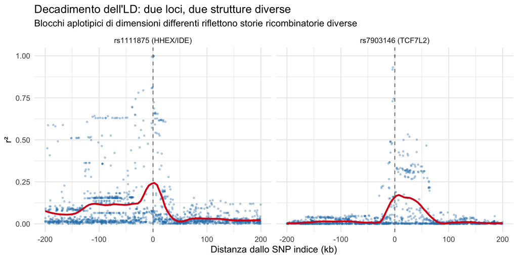

Decadimento LD a confronto su due loci diversi

```r
ggplot(ld_both, aes(x = dist_kb, y = r2)) +
  geom_point(alpha = 0.3, color = "#2c7fb8", size = 0.7) +
  geom_smooth(method = "loess", span = 0.2, color = "#d7191c", se = FALSE) +
  geom_vline(xintercept = 0, linetype = "dashed", color = "grey50") +
  facet_wrap(~ locus) +
  labs(
    x = "Distanza dallo SNP indice (kb)", y = "r²",
    title = "Decadimento dell'LD: due loci, due strutture diverse",
    subtitle = "Blocchi aplotipici di dimensioni differenti riflettono storie ricombinatorie diverse"
  )
```

## 2c. Quantificare la dimensione del blocco LD

```r
# Definiamo "dimensione del blocco" come l'estensione in kb entro cui r² >= 0.5
block_extent <- function(ld_df, threshold = 0.5) {
  high_ld <- ld_df[ld_df$r2 >= threshold & ld_df$dist_kb != 0, ]
  if (nrow(high_ld) == 0) return(0)
  diff(range(high_ld$dist_kb))
}

data.frame(
  locus = c(paste0(locus1_id, " (TCF7L2)"),
            paste0(locus2_id, " (", locus2_name, ")")),
  n_snp_r2_over_0.8 = c(sum(ld1$r2 >= 0.8) - 1, sum(ld2$r2 >= 0.8) - 1),
  block_kb_r2_over_0.5 = c(round(block_extent(ld1), 1),
                           round(block_extent(ld2), 1))
)
```

| locus | n_snp_r2_over_0.8 | block_kb_r2_over_0.5 |
| --- | --- | --- |
| rs7903146 (TCF7L2) | 2 | 45.1 |
| rs1111875 (HHEX/IDE) | 7 | 217.5 |

**Cosa osservare:** i due loci hanno blocchi di dimensioni diverse. Un blocco esteso indica una regione con poca ricombinazione storica (pochi hotspot); un blocco piccolo indica ricombinazione frequente. Questo ha conseguenze pratiche: in un blocco grande pochi tag SNP catturano tutta la regione, ma è più difficile fare fine-mapping (la variante causale è “nascosta” tra molti SNP correlati).

3. **Costruzione delle prime tre sezioni dello scheletro `.Rmd` di progetto**: caricamento, statistiche descrittive, plot di LD.

Adesso tocca a voi usare il dataset HTN_chr16 e iniziare ad impostare il notebook per l’esame.

# Appendice — Comandi rapidi da ricordare

| Operazione | Codice |
| --- | --- |
| Caricare PLINK | `dat <- genio::read_plink("path_senza_estensione")` |
| Matrice genotipi | `G <- dat$X` (n_snp × n_ind) |
| Frequenza allele ALT | `freq <- rowMeans(G, na.rm = TRUE) / 2` |
| MAF | `maf <- pmin(freq, 1 - freq)` |
| HWE su tutti gli SNP | `snpStats::col.summary(snp_mat)$z.HWE` |
| LD pairwise r² | `cor(G[i, ], G[j, ], use = "pairwise.complete.obs")^2` |
| LD heatmap pronta | `LDheatmap::LDheatmap(snp_mat[, idx], genetic.distances = pos[idx])` |

**Tutta la pipeline GWAS è una sequenza di operazioni sulla matrice `G`.** Da qui partiremo per il resto del corso.